# Data Mining Small Project Late 2022

Nguyen Minh Tien

31/12/2022

# I. Project Target

NBA player longevity prediction.

The data set consist of information about NBA (National Basketball Association) players and if their career was longer than 5 years or not. A predictive model could be useful when contracting players, deciding of how long a contract with the player should last. Please build a predictive model, that estimates the longevity of players career (if it is longer than 5 years or not) using game statistics measures.

## II. Problem Statement

The data set details the performance metrics of NBA players and whether their careers span more than 5 years or not. The task is to predict the career length using machine learning model.

### 1. What types of machine learning models perform best on this data set?

Since we only need to predict whether a NBA player’s career will last for more than 5 years or not, the machine learning model perform best on this data set is Binary Classification, in this assignment, I will use Logistic Regression.

And I will use another model that is Decision Tree and compare the accuracy between them two. The result which model perform best on this data set will be in the section VIII.3

### 2. Which features are most indicative of the players’ career length?

As the result in VII.4, we find that points_per_game is the most indicative feature. Following are min_per_game and assist_per_game.

## III. Reading the Data and Import Libraries

```r
# Data imported as NBA_players
NBA_players<-read.table("./61_nba_data.csv", header = T, sep = ",", stringsAsFactors = T)
players<-read.table("./61_nba_data.csv", header = T, sep = ",", stringsAsFactors = T)
```

```r
if (!require('tidyverse')) install.packages('tidyverse'); library('tidyverse')
```

```r
if (!require('ggplot2')) install.packages('ggplot2'); library('ggplot2')
if (!require('caTools')) install.packages('caTools'); library('caTools')
if (!require('ROCR')) install.packages('ROCR'); library('ROCR')
if (!require('rpart')) install.packages('rpart'); library('rpart')
if (!require('rpart.plot')) install.packages('rpart.plot'); library('rpart.plot')
```

## IV. Data Summary

First, we look at the summary of the data:

```r
glimpse(NBA_players)
```

```
## Rows: 496
## Columns: 21
## $ Name        <fct> "Brandon Ingram", "Andrew Harrison", "JaKarr Sampson", "Ma…
## $ GP          <int> 36, 35, 74, 58, 48, 75, 62, 48, 65, 42, 35, 40, 27, 45, 44…
## $ MIN         <dbl> 27.4, 26.9, 15.3, 11.6, 11.5, 11.4, 10.9, 10.3, 9.9, 8.5, …
## $ PTS         <dbl> 7.4, 7.2, 5.2, 5.7, 4.5, 3.7, 6.6, 5.7, 2.4, 3.7, 2.3, 3.6…
## $ FGM         <dbl> 2.6, 2.0, 2.0, 2.3, 1.6, 1.5, 2.5, 2.3, 1.0, 1.4, 0.9, 1.2…
## $ FGA         <dbl> 7.6, 6.7, 4.7, 5.5, 3.0, 3.5, 5.8, 5.4, 2.4, 3.5, 2.4, 3.0…
## $ FG.         <dbl> 34.7, 29.6, 42.2, 42.6, 52.4, 42.3, 43.5, 41.5, 39.2, 38.3…
## $ X3P.Made    <dbl> 0.5, 0.7, 0.4, 0.1, 0.0, 0.3, 0.0, 0.4, 0.1, 0.1, 0.0, 0.1…
## $ X3PA        <dbl> 2.1, 2.8, 1.7, 0.5, 0.1, 1.1, 0.1, 1.5, 0.5, 0.3, 0.1, 0.6…
## $ X3P.        <dbl> 25.0, 23.5, 24.4, 22.6, 0.0, 32.5, 50.0, 30.0, 23.3, 21.4,…
## $ FTM         <dbl> 1.6, 2.6, 0.9, 0.9, 1.3, 0.4, 1.5, 0.7, 0.4, 1.0, 0.5, 1.1…
## $ FTA         <dbl> 2.3, 3.4, 1.3, 1.3, 1.9, 0.5, 1.8, 0.8, 0.5, 1.4, 0.6, 1.5…
## $ FT.         <dbl> 69.9, 76.5, 67.0, 68.9, 67.4, 73.2, 81.1, 87.5, 71.4, 67.8…
## $ OREB        <dbl> 0.7, 0.5, 0.5, 1.0, 1.0, 0.2, 0.5, 0.8, 0.2, 0.4, 0.5, 0.5…
## $ DREB        <dbl> 3.4, 2.0, 1.7, 0.9, 1.5, 0.7, 1.4, 0.9, 0.6, 0.7, 0.3, 0.8…
## $ REB         <dbl> 4.1, 2.4, 2.2, 1.9, 2.5, 0.8, 2.0, 1.7, 0.8, 1.1, 0.9, 1.2…
## $ AST         <dbl> 1.9, 3.7, 1.0, 0.8, 0.3, 1.8, 0.6, 0.2, 2.3, 0.3, 0.7, 0.4…
## $ STL         <dbl> 0.4, 1.1, 0.5, 0.6, 0.3, 0.4, 0.2, 0.2, 0.3, 0.2, 0.1, 0.3…
## $ BLK         <dbl> 0.4, 0.5, 0.3, 0.1, 0.4, 0.0, 0.1, 0.1, 0.0, 0.0, 0.1, 0.1…
## $ TOV         <dbl> 1.3, 1.6, 1.0, 1.0, 0.8, 0.7, 0.7, 0.7, 1.1, 0.7, 0.3, 0.6…
## $ TARGET_5Yrs <int> 0, 0, 0, 1, 1, 0, 1, 1, 0, 0, 0, 1, 1, 0, 1, 1, 0, 0, 0, 1…
```

In total, the data set contains 496 NBA players information. Each player has 20 specifications or attributes that we can predict whether or not they can have career length greater than 5. The 21th column is a Boolean value, 0 when that player has career length < 5 and 1 when that player has career length > 5.

## V. Data Preparation

### 1. Data Cleaning

Some data may be “NA” value which is not good for prediction, let’s check if there is any NA value in the data set.

```r
map_dbl(NBA_players, function(.x) {sum(is.na(.x))})
```

```
##        Name          GP         MIN         PTS         FGM         FGA
##           0           0           0           0           0           0
##         FG.    X3P.Made        X3PA        X3P.         FTM         FTA
##           0           0           0           1           0           0
##         FT.        OREB        DREB         REB         AST         STL
##           0           0           0           0           0           0
##         BLK         TOV TARGET_5Yrs
##           0           0           0
```

Since there is only one row have X3P. field as NA values, we will drop that row.

```r
for(i in 1:496){
  if (is.na(NBA_players[i,"X3P."])) {
    print(i)
  }
}
```

```
## [1] 121
```

Delete the 121th row which is the row contain NA value

```r
NBA_players <- NBA_players[-121,]
```

We check again if the data is fine now:

```r
map_dbl(NBA_players, function(.x) {sum(is.na(.x))})
```

```
##        Name          GP         MIN         PTS         FGM         FGA
##           0           0           0           0           0           0
##         FG.    X3P.Made        X3PA        X3P.         FTM         FTA
##           0           0           0           0           0           0
##         FT.        OREB        DREB         REB         AST         STL
##           0           0           0           0           0           0
##         BLK         TOV TARGET_5Yrs
##           0           0           0
```

Now there is no missing data from the data set.

### 2. Data Formatting

Total assists made, total minutes played etc do not take into account the number of games played as well. IE, it may be possible that a certain player has more minutes in one game while he has less in the other.

So, it’s better to have metrics like minutes, rebounds, assists, steals etc seen per game.

```r
NBA_players["min/game"] <- NBA_players["MIN"]/NBA_players["GP"]
NBA_players["rebound/game"] = NBA_players["REB"]/NBA_players["GP"]
NBA_players["assist/game"] = NBA_players["AST"]/NBA_players["GP"]
NBA_players["steals/game"] = NBA_players["STL"]/NBA_players["GP"]
NBA_players["blocks/game"] = NBA_players["BLK"]/NBA_players["GP"]
NBA_players["turnovers/game"] = NBA_players["TOV"]/NBA_players["GP"]
NBA_players["5_years?"] = NBA_players["TARGET_5Yrs"]
```

### 3. Removing columns not needed for the model

```r
NBA_players <- NBA_players[,!names(NBA_players) %in% c("Name","GP", "MIN", "FGM", "FGA",
                                                       "X3P.Made", "X3PA", "FTM",
                                                       "FTA", "OREB", "DREB", "REB",
                                                       "AST", "STL", "BLK", "TOV",
                                                       "TARGET_5Yrs")]
```

### 4. Giving the columns convenient names

```r
colnames(NBA_players) <- c("points_per_game", "field_goal_percentage",
                           "three_points_percentage", "free_throw_percentage",
                           "min_per_game", "rebound_per_game", "assist_per_game",
                           "steals_per_game", "blocks_per_game", "turnovers_per_game", "outcome")
```

### 5. Final Data Prepared

```r
glimpse(NBA_players)
```

```
## Rows: 495
## Columns: 11
## $ points_per_game         <dbl> 7.4, 7.2, 5.2, 5.7, 4.5, 3.7, 6.6, 5.7, 2.4, 3…
## $ field_goal_percentage   <dbl> 34.7, 29.6, 42.2, 42.6, 52.4, 42.3, 43.5, 41.5…
## $ three_points_percentage <dbl> 25.0, 23.5, 24.4, 22.6, 0.0, 32.5, 50.0, 30.0,…
## $ free_throw_percentage   <dbl> 69.9, 76.5, 67.0, 68.9, 67.4, 73.2, 81.1, 87.5…
## $ min_per_game            <dbl> 0.7611111, 0.7685714, 0.2067568, 0.2000000, 0.…
## $ rebound_per_game        <dbl> 0.113888889, 0.068571429, 0.029729730, 0.03275…
## $ assist_per_game         <dbl> 0.052777778, 0.105714286, 0.013513514, 0.01379…
## $ steals_per_game         <dbl> 0.011111111, 0.031428571, 0.006756757, 0.01034…
## $ blocks_per_game         <dbl> 0.011111111, 0.014285714, 0.004054054, 0.00172…
## $ turnovers_per_game      <dbl> 0.036111111, 0.045714286, 0.013513514, 0.01724…
## $ outcome                 <int> 0, 0, 0, 1, 1, 0, 1, 1, 0, 0, 0, 1, 1, 0, 1, 1…
```

Now we done data preparation and data understanding, we move to Data Visualization.

## VI. Data Visualization

In this part, I will use the raw data for visualization.

TARGET_5Yrs/Outcome is the response variable having either 1 or 0. How many rows having class 1 and how many rows having class 0?

295 data rows belong to class 1 and 200 data rows belong to class 0.

```r
outcome <- as.data.frame(table(NBA_players["outcome"]))
outcome
```

```
##   outcome Freq
## 1       0  200
## 2       1  295
```

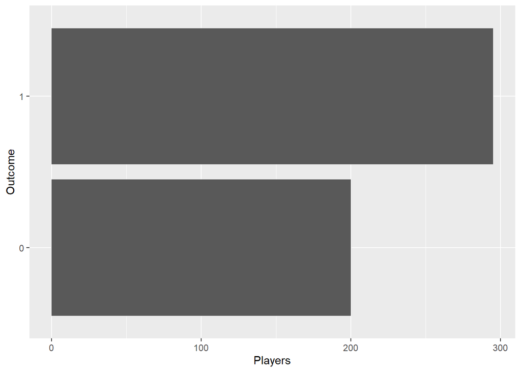

```r
ggplot(outcome, aes(x = Freq, y = outcome)) +
  geom_bar(stat = "identity") +
  labs(x = "Players", y = "Outcome")
```

Exploring the data points further with box plots and scatter plots. Very clear that the number of years more in the career then the Games Played, Minutes Played, Points Per Game and Turnovers are more. The scatter plots clearly show strong correlation between Games Played and Minutes Played, Games Played and Points Per Game, Minutes Played and Points Per Game, Offensive Rebounds and Defensive Rebounds.

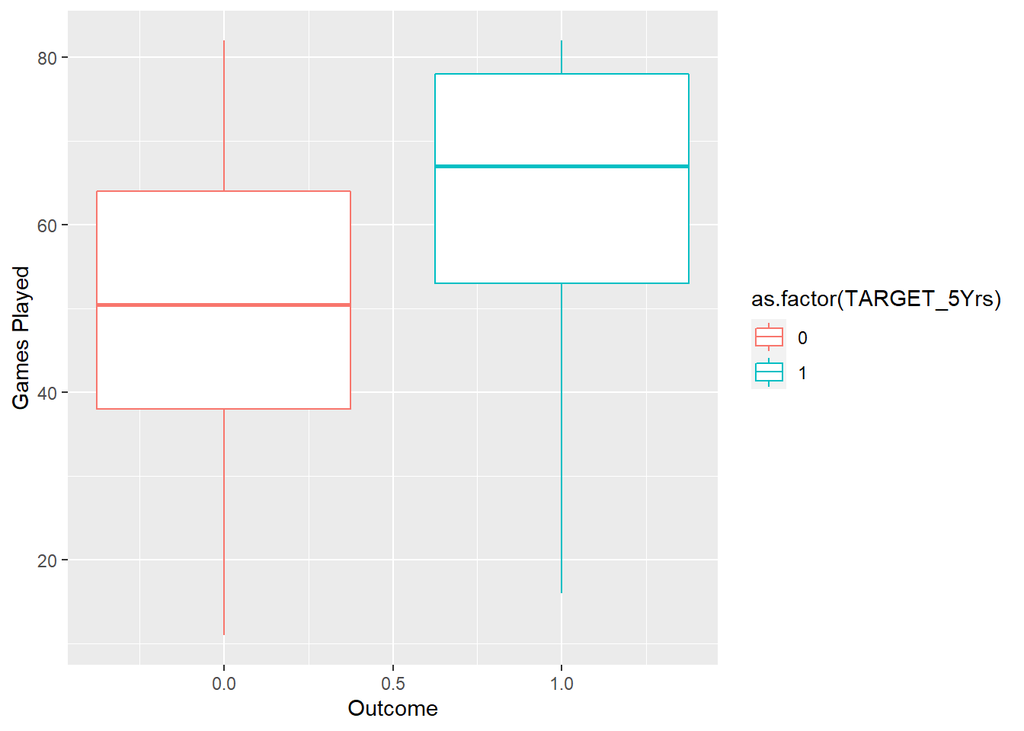

```r
ggplot(players, aes(x = TARGET_5Yrs, y = GP, col = as.factor(TARGET_5Yrs))) +
  geom_boxplot() +
  labs(x = "Outcome", y = "Games Played")
```

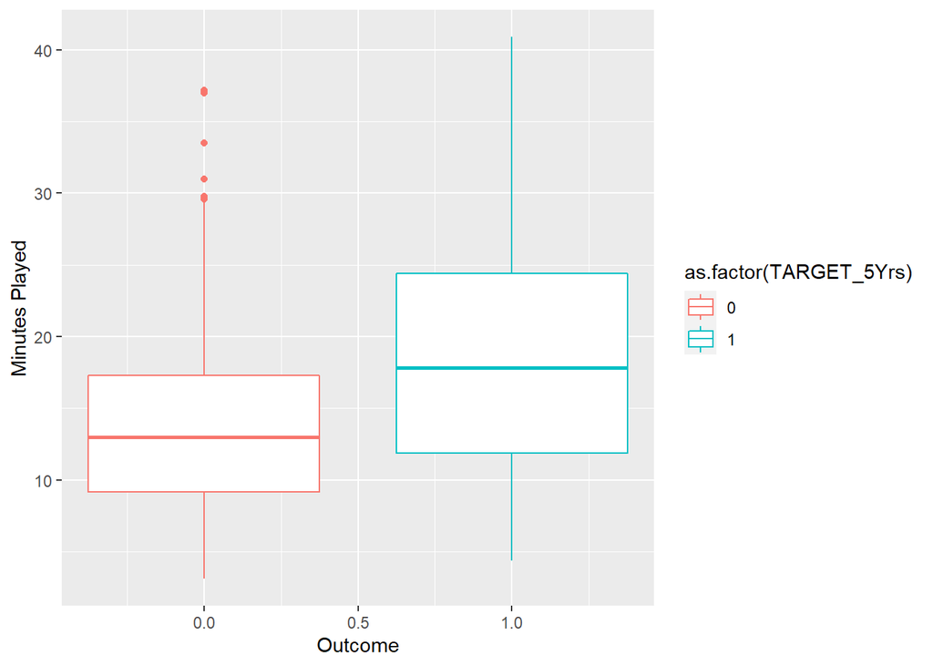

```r
ggplot(players, aes(x = TARGET_5Yrs, y = MIN, col = as.factor(TARGET_5Yrs))) +
  geom_boxplot() +
  labs(x = "Outcome", y = "Minutes Played")
```

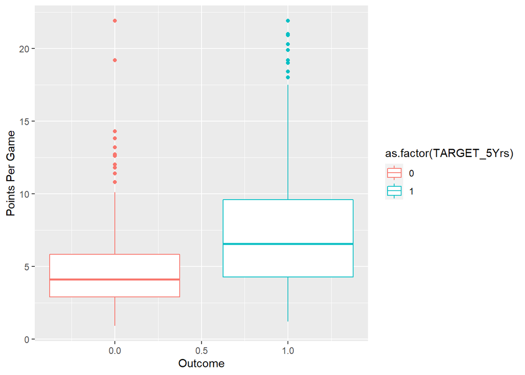

```r
ggplot(players, aes(x = TARGET_5Yrs, y = PTS, col = as.factor(TARGET_5Yrs))) +
  geom_boxplot() +
  labs(x = "Outcome", y = "Points Per Game")
```

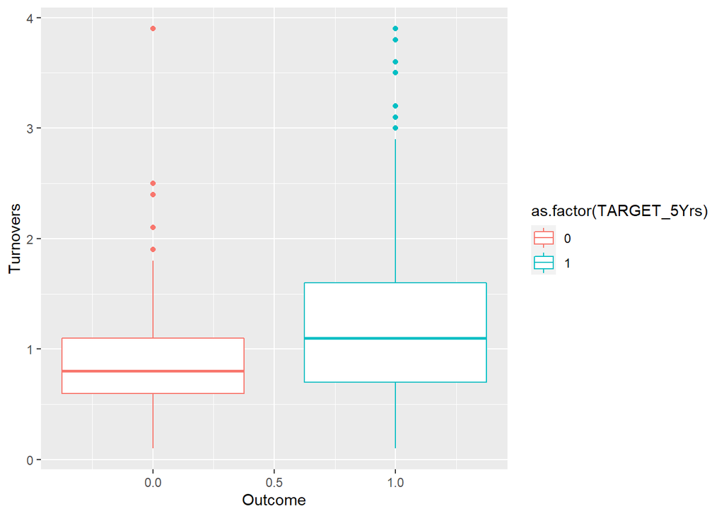

```r
ggplot(players, aes(x = TARGET_5Yrs, y = TOV, col = as.factor(TARGET_5Yrs))) +
  geom_boxplot() +
  labs(x = "Outcome", y = "Turnovers")
```

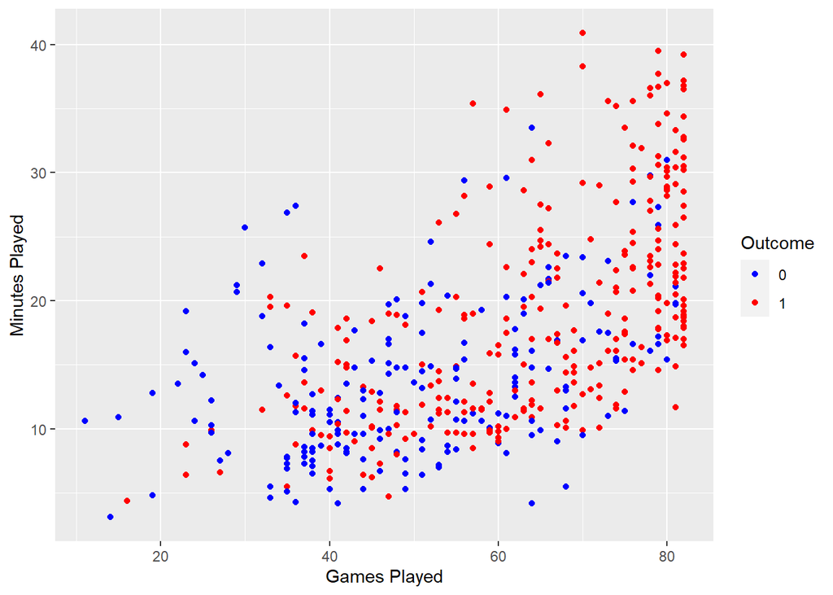

```r
ggplot(players, aes(x = GP, y = MIN, col = as.factor(TARGET_5Yrs))) +
  geom_point() +
  scale_color_manual(breaks = c(0, 1), values = c("blue", "red")) +
  labs(x = "Games Played", y = "Minutes Played", col = "Outcome")
```

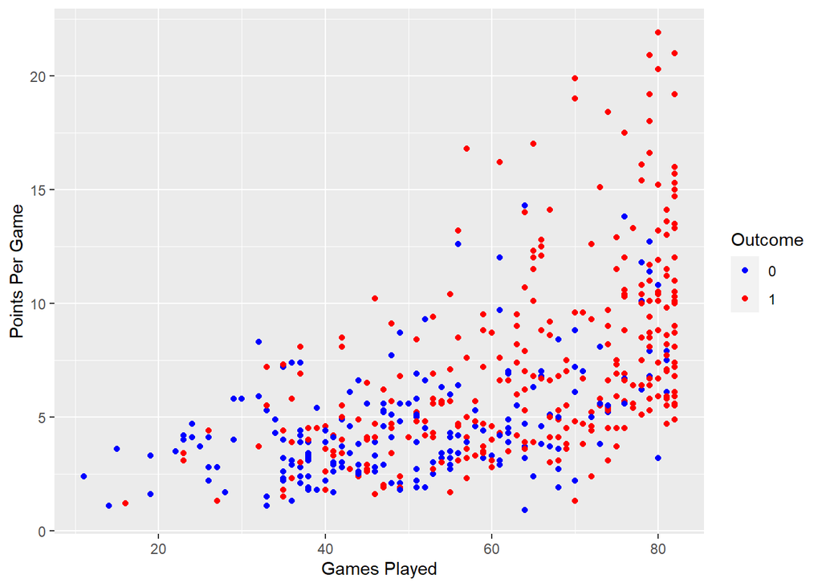

```r
ggplot(players, aes(x = GP, y = PTS, col = as.factor(TARGET_5Yrs))) +
  geom_point() +
  scale_color_manual(breaks = c(0, 1), values = c("blue", "red")) +
  labs(x = "Games Played", y = "Points Per Game", col = "Outcome")
```

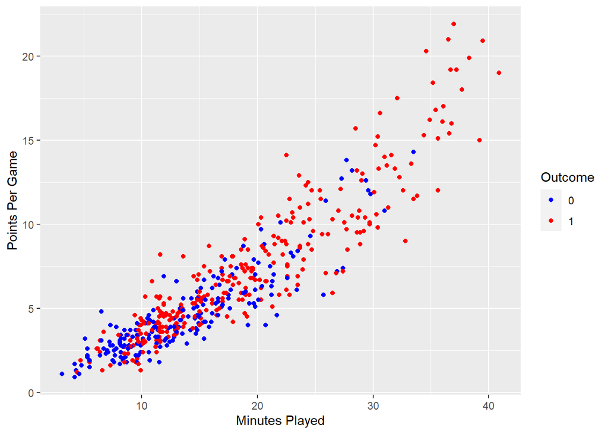

```r
ggplot(players, aes(x = MIN, y = PTS, col = as.factor(TARGET_5Yrs))) +
  geom_point() +
  scale_color_manual(breaks = c(0, 1), values = c("blue", "red")) +
  labs(x = "Minutes Played", y = "Points Per Game", col = "Outcome")
```

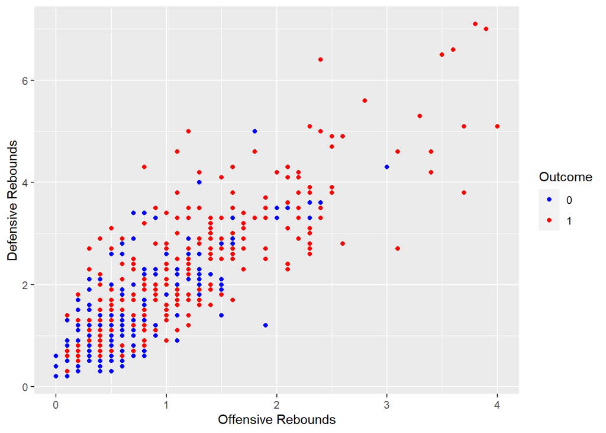

```r
ggplot(players, aes(x = OREB, y = DREB, col = as.factor(TARGET_5Yrs))) +
  geom_point() +
  scale_color_manual(breaks = c(0, 1), values = c("blue", "red")) +
  labs(x = "Offensive Rebounds", y = "Defensive Rebounds", col = "Outcome")
```

## VII. Models

### 1. Models Break-down

#### a. Logistic Regression

Logistic regression in R Programming is a classification algorithm used to find the probability of event success and event failure. Logistic regression is used when the dependent variable is binary(0/1, True/False, Yes/No) in nature. Logit function is used as a link function in a binomial distribution.

#### b. Decision Tree

Decision tree is a graph to represent choices and their results in form of a tree. The nodes in the graph represent an event or choice and the edges of the graph represent the decision rules or conditions. It is mostly used in Machine Learning and Data Mining applications using R.

### 2. Creating train and test dataframes

```r
# Choose how much percentage you want for training set
training_set_percentage <- 80 # 80%

# Splitting data set
split <- sample.split(NBA_players, SplitRatio = training_set_percentage/100)
split
```

```
##  [1] FALSE FALSE  TRUE  TRUE  TRUE  TRUE  TRUE  TRUE  TRUE  TRUE FALSE
```

```r
train_set <- subset(NBA_players, split == "TRUE")
test_set <- subset(NBA_players, split == "FALSE")
```

Training Set Summary

```r
glimpse(train_set)
```

```
## Rows: 360
## Columns: 11
## $ points_per_game         <dbl> 5.2, 5.7, 4.5, 3.7, 6.6, 5.7, 2.4, 3.7, 5.6, 2…
## $ field_goal_percentage   <dbl> 42.2, 42.6, 52.4, 42.3, 43.5, 41.5, 39.2, 38.3…
## $ three_points_percentage <dbl> 24.4, 22.6, 0.0, 32.5, 50.0, 30.0, 23.3, 21.4,…
## $ free_throw_percentage   <dbl> 67.0, 68.9, 67.4, 73.2, 81.1, 87.5, 71.4, 67.8…
## $ min_per_game            <dbl> 0.2067568, 0.2000000, 0.2395833, 0.1520000, 0.…
## $ rebound_per_game        <dbl> 0.029729730, 0.032758621, 0.052083333, 0.01066…
## $ assist_per_game         <dbl> 0.013513514, 0.013793103, 0.006250000, 0.02400…
## $ steals_per_game         <dbl> 0.006756757, 0.010344828, 0.006250000, 0.00533…
## $ blocks_per_game         <dbl> 0.004054054, 0.001724138, 0.008333333, 0.00000…
## $ turnovers_per_game      <dbl> 0.013513514, 0.017241379, 0.016666667, 0.00933…
## $ outcome                 <int> 0, 1, 1, 0, 1, 1, 0, 0, 0, 1, 1, 0, 0, 0, 1, 1…
```

Testing Set Summary

```r
glimpse(test_set)
```

```
## Rows: 135
## Columns: 11
## $ points_per_game         <dbl> 7.4, 7.2, 2.3, 3.6, 1.3, 10.6, 12.0, 10.4, 4.3…
## $ field_goal_percentage   <dbl> 34.7, 29.6, 36.5, 39.8, 47.2, 37.5, 45.4, 51.4…
## $ three_points_percentage <dbl> 25.0, 23.5, 33.3, 13.6, 0.0, 13.3, 32.0, 0.0, …
## $ free_throw_percentage   <dbl> 69.9, 76.5, 81.8, 77.6, 28.6, 73.0, 74.8, 80.7…
## $ min_per_game            <dbl> 0.7611111, 0.7685714, 0.1971429, 0.1675000, 0.…
## $ rebound_per_game        <dbl> 0.11388889, 0.06857143, 0.02571429, 0.03000000…
## $ assist_per_game         <dbl> 0.052777778, 0.105714286, 0.020000000, 0.01000…
## $ steals_per_game         <dbl> 0.011111111, 0.031428571, 0.002857143, 0.00750…
## $ blocks_per_game         <dbl> 0.011111111, 0.014285714, 0.002857143, 0.00250…
## $ turnovers_per_game      <dbl> 0.036111111, 0.045714286, 0.008571429, 0.01500…
## $ outcome                 <int> 0, 0, 0, 1, 1, 1, 0, 1, 0, 1, 1, 1, 1, 0, 0, 0…
```

### 3. Training Model

#### a. Logistic Regression

```r
logistic_model <- glm(outcome ~.,family=binomial(link='logit'),data=NBA_players)
```

#### b. Decision Tree

```r
decisiontree_model <- rpart(outcome ~., data = NBA_players, method = "class")
```

### 4. Model Summary

As the Summary, we find that points_per_game is the most indicative feature. Following are min_per_game and assist_per_game. #### a. Logistic Regression

```r
summary(logistic_model)
```

```
##
## Call:
## glm(formula = outcome ~ ., family = binomial(link = "logit"),
##     data = NBA_players)
##
## Deviance Residuals:
##     Min       1Q   Median       3Q      Max
## -3.2266  -1.0484   0.5293   0.9114   2.2475
##
## Coefficients:
##                           Estimate Std. Error z value Pr(>|z|)
## (Intercept)              -3.015404   1.327043  -2.272  0.02307 *
## points_per_game           0.291891   0.047046   6.204 5.49e-10 ***
## field_goal_percentage     0.047301   0.021991   2.151  0.03149 *
## three_points_percentage  -0.001038   0.007675  -0.135  0.89241
## free_throw_percentage     0.015449   0.011416   1.353  0.17597
## min_per_game             -6.325574   2.342991  -2.700  0.00694 **
## rebound_per_game         13.214259   8.263457   1.599  0.10979
## assist_per_game          33.196202  10.517212   3.156  0.00160 **
## steals_per_game         -13.568670  26.707465  -0.508  0.61142
## blocks_per_game          39.038265  26.016130   1.501  0.13347
## turnovers_per_game      -62.334442  24.453635  -2.549  0.01080 *
## ---
## Signif. codes:  0 '***' 0.001 '**' 0.01 '*' 0.05 '.' 0.1 ' ' 1
##
## (Dispersion parameter for binomial family taken to be 1)
##
##     Null deviance: 667.87  on 494  degrees of freedom
## Residual deviance: 558.72  on 484  degrees of freedom
## AIC: 580.72
##
## Number of Fisher Scoring iterations: 4
```

#### b. Decision Tree

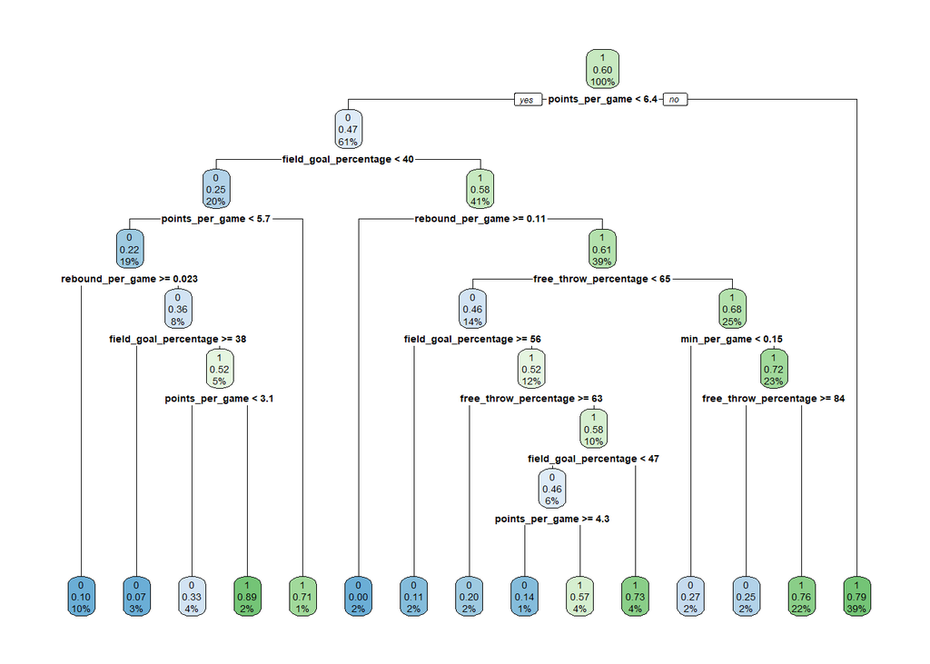

```r
rpart.plot(decisiontree_model)
```

## VIII. Model’s evaluation

### 1. Predict test data based on model

```r
predict <- predict(logistic_model, test_set, type = "response")
predict
```

```
##          1          2         11         12         13         22         23
## 0.15636000 0.17935118 0.47671067 0.45819975 0.44803774 0.50374237 0.78200908
##         24         33         34         35         44         45         46
## 0.87405194 0.57263970 0.37915363 0.70731174 0.64367153 0.81469911 0.03435291
##         55         56         57         66         67         68         77
## 0.43379987 0.44289482 0.47516454 0.87138051 0.78435854 0.87103932 0.52447986
##         78         79         88         89         90         99        100
## 0.61153262 0.68768302 0.50382714 0.51267368 0.46228230 0.44531778 0.67347182
##        101        110        111        112        122        123        124
## 0.41626233 0.86691436 0.83117591 0.72369882 0.85859200 0.66948863 0.28194907
##        133        134        135        144        145        146        155
## 0.66891113 0.12805986 0.52564478 0.26696627 0.78695772 0.67783501 0.59393149
##        156        157        166        167        168        177        178
## 0.42969546 0.67231620 0.25032453 0.68785714 0.43442691 0.45408524 0.77836771
##        179        188        189        190        199        200        201
## 0.39874051 0.46209645 0.11873208 0.18021449 0.67225938 0.45472938 0.31228966
##        210        211        212        221        222        223        232
## 0.81153833 0.78270108 0.44464218 0.42470524 0.69383694 0.57402921 0.44146543
##        233        234        243        244        245        254        255
## 0.51547018 0.04531275 0.55518315 0.82553514 0.67109221 0.39092646 0.33116437
##        256        265        266        267        276        277        278
## 0.69461047 0.73549038 0.60232949 0.44764007 0.87163535 0.93042275 0.64007833
##        287        288        289        298        299        300        309
## 0.73529770 0.78147414 0.70167785 0.41646096 0.70224996 0.32326909 0.33005421
##        310        311        320        321        322        331        332
## 0.47698014 0.95494250 0.74997626 0.60076201 0.01722008 0.47831656 0.49823368
##        333        342        343        344        353        354        355
## 0.43112088 0.96630545 0.86063266 0.82264286 0.39114197 0.55214513 0.85155791
##        364        365        366        375        376        377        386
## 0.33591470 0.52831148 0.58068980 0.54935288 0.56752605 0.45445289 0.84450656
##        387        388        397        398        399        408        409
## 0.91862504 0.72101032 0.37738686 0.66878401 0.68777817 0.59176899 0.54269396
##        410        419        420        421        430        431        432
## 0.41409456 0.93967596 0.93967596 0.90991314 0.86470979 0.62760412 0.85568506
##        441        442        443        452        453        454        463
## 0.76654603 0.29934075 0.70918296 0.38798462 0.45216688 0.34391095 0.91601437
##        464        465        474        475        476        485        486
## 0.77864568 0.84075653 0.67960617 0.72466667 0.56285755 0.55212634 0.48831040
##        487        496
## 0.58820451 0.57136075
```

```r
predict_dt <- predict(decisiontree_model, test_set, type = "class")
predict_dt
```

```
##   1   2  11  12  13  22  23  24  33  34  35  44  45  46  55  56  57  66  67  68
##   1   1   0   1   1   1   1   1   0   1   1   1   1   0   1   1   0   1   1   1
##  77  78  79  88  89  90  99 100 101 110 111 112 122 123 124 133 134 135 144 145
##   1   0   1   1   0   0   0   0   1   1   1   1   1   1   0   0   0   1   0   1
## 146 155 156 157 166 167 168 177 178 179 188 189 190 199 200 201 210 211 212 221
##   1   1   1   1   1   1   1   0   1   0   1   0   0   1   1   0   1   1   1   1
## 222 223 232 233 234 243 244 245 254 255 256 265 266 267 276 277 278 287 288 289
##   1   1   0   0   0   1   1   1   1   0   1   0   0   1   1   1   1   1   0   1
## 298 299 300 309 310 311 320 321 322 331 332 333 342 343 344 353 354 355 364 365
##   1   1   1   1   1   1   1   1   0   0   1   1   1   1   1   1   1   1   0   1
## 366 375 376 377 386 387 388 397 398 399 408 409 410 419 420 421 430 431 432 441
##   1   1   0   1   1   1   1   1   1   1   1   1   1   1   1   1   1   1   1   1
## 442 443 452 453 454 463 464 465 474 475 476 485 486 487 496
##   0   0   0   0   0   1   1   1   1   1   1   1   1   1   1
## Levels: 0 1
```

### 2. Turn Probabilities into Results

```r
predict <- ifelse(predict >0.5, 1, 0)
predict
```

```
##   1   2  11  12  13  22  23  24  33  34  35  44  45  46  55  56  57  66  67  68
##   0   0   0   0   0   1   1   1   1   0   1   1   1   0   0   0   0   1   1   1
##  77  78  79  88  89  90  99 100 101 110 111 112 122 123 124 133 134 135 144 145
##   1   1   1   1   1   0   0   1   0   1   1   1   1   1   0   1   0   1   0   1
## 146 155 156 157 166 167 168 177 178 179 188 189 190 199 200 201 210 211 212 221
##   1   1   0   1   0   1   0   0   1   0   0   0   0   1   0   0   1   1   0   0
## 222 223 232 233 234 243 244 245 254 255 256 265 266 267 276 277 278 287 288 289
##   1   1   0   1   0   1   1   1   0   0   1   1   1   0   1   1   1   1   1   1
## 298 299 300 309 310 311 320 321 322 331 332 333 342 343 344 353 354 355 364 365
##   0   1   0   0   0   1   1   1   0   0   0   0   1   1   1   0   1   1   0   1
## 366 375 376 377 386 387 388 397 398 399 408 409 410 419 420 421 430 431 432 441
##   1   1   1   0   1   1   1   0   1   1   1   1   0   1   1   1   1   1   1   1
## 442 443 452 453 454 463 464 465 474 475 476 485 486 487 496
##   0   1   0   0   0   1   1   1   1   1   1   1   0   1   1
```

```r
predict_dt
```

```
##   1   2  11  12  13  22  23  24  33  34  35  44  45  46  55  56  57  66  67  68
##   1   1   0   1   1   1   1   1   0   1   1   1   1   0   1   1   0   1   1   1
##  77  78  79  88  89  90  99 100 101 110 111 112 122 123 124 133 134 135 144 145
##   1   0   1   1   0   0   0   0   1   1   1   1   1   1   0   0   0   1   0   1
## 146 155 156 157 166 167 168 177 178 179 188 189 190 199 200 201 210 211 212 221
##   1   1   1   1   1   1   1   0   1   0   1   0   0   1   1   0   1   1   1   1
## 222 223 232 233 234 243 244 245 254 255 256 265 266 267 276 277 278 287 288 289
##   1   1   0   0   0   1   1   1   1   0   1   0   0   1   1   1   1   1   0   1
## 298 299 300 309 310 311 320 321 322 331 332 333 342 343 344 353 354 355 364 365
##   1   1   1   1   1   1   1   1   0   0   1   1   1   1   1   1   1   1   0   1
## 366 375 376 377 386 387 388 397 398 399 408 409 410 419 420 421 430 431 432 441
##   1   1   0   1   1   1   1   1   1   1   1   1   1   1   1   1   1   1   1   1
## 442 443 452 453 454 463 464 465 474 475 476 485 486 487 496
##   0   0   0   0   0   1   1   1   1   1   1   1   1   1   1
## Levels: 0 1
```

### 3. Evaluating model accuracy using confusion matrix

Confusion Matrix:

```r
# Logistic Regression
table(test_set$outcome, predict)
```

```
##    predict
##      0  1
##   0 35 23
##   1 16 61
```

```r
# Decision Tree
table(test_set$outcome, predict_dt)
```

```
##    predict_dt
##      0  1
##   0 32 26
##   1  2 75
```

Below is the accuracy using Logistic Regression Model:

```r
missing_classerr <- mean(predict != test_set$outcome)
print(paste('Accuracy Logistic Regression =', 1 - missing_classerr))
```

```
## [1] "Accuracy Logistic Regression = 0.711111111111111"
```

```r
a_lr = 1 - missing_classerr
```

Below is the accuracy using Decision Tree Model:

```r
missing_classerr_dt <- mean(predict_dt != test_set$outcome)
print(paste('Accuracy Decision Tree =', 1 - missing_classerr_dt))
```

```
## [1] "Accuracy Decision Tree = 0.792592592592593"
```

```r
a_dt = 1 - missing_classerr_dt
```

As the result, the best model for the most accuracy is:

```r
if(a_lr > a_dt){
  print("Logistic Regression")
} else{
  print("Decision Tree")
}
```

```
## [1] "Decision Tree"
```

## IX. Answer for the question related to the new data set

### 1. Import new data set

```r
new_NBA_players<-read.table("./62_nba_newdata_no_labels.csv", header = T, sep = ",", stringsAsFactors = T)
new_players<-read.table("./62_nba_newdata_no_labels.csv", header = T, sep = ",", stringsAsFactors = T)
```

### 2. Check if the data set is clean

```r
map_dbl(new_NBA_players, function(.x) {sum(is.na(.x))})
```

```
##     Name       GP      MIN      PTS      FGM      FGA      FG. X3P.Made
##        0        0        0        0        0        0        0        0
##     X3PA     X3P.      FTM      FTA      FT.     OREB     DREB      REB
##        0        0        0        0        0        0        0        0
##      AST      STL      BLK      TOV
##        0        0        0        0
```

Data is clean as no NA value.

### 3. Data Preparation

```r
new_NBA_players["min/game"] <- new_NBA_players["MIN"]/new_NBA_players["GP"]
new_NBA_players["rebound/game"] = new_NBA_players["REB"]/new_NBA_players["GP"]
new_NBA_players["assist/game"] = new_NBA_players["AST"]/new_NBA_players["GP"]
new_NBA_players["steals/game"] = new_NBA_players["STL"]/new_NBA_players["GP"]
new_NBA_players["blocks/game"] = new_NBA_players["BLK"]/new_NBA_players["GP"]
new_NBA_players["turnovers/game"] = new_NBA_players["TOV"]/new_NBA_players["GP"]

new_NBA_players <- new_NBA_players[,!names(new_NBA_players) %in% c("Name","GP", "MIN", "FGM", "FGA",
                                                       "X3P.Made", "X3PA", "FTM",
                                                       "FTA", "OREB", "DREB", "REB",
                                                       "AST", "STL", "BLK", "TOV")]

colnames(new_NBA_players) <- c("points_per_game", "field_goal_percentage",
                           "three_points_percentage", "free_throw_percentage",
                           "min_per_game", "rebound_per_game", "assist_per_game",
                           "steals_per_game", "blocks_per_game", "turnovers_per_game")

glimpse(new_NBA_players)
```

```
## Rows: 20
## Columns: 10
## $ points_per_game         <dbl> 10.2, 6.6, 3.4, 4.7, 2.2, 4.6, 10.3, 6.3, 3.5,…
## $ field_goal_percentage   <dbl> 49.9, 40.7, 30.4, 33.7, 34.8, 41.2, 49.8, 53.3…
## $ three_points_percentage <dbl> 0.0, 23.5, 20.4, 26.9, 27.3, 0.0, 21.4, 0.0, 0…
## $ free_throw_percentage   <dbl> 66.3, 79.7, 74.5, 73.9, 64.3, 64.0, 72.7, 62.5…
## $ min_per_game            <dbl> 0.2746835, 0.2736842, 0.2381818, 0.7388889, 0.…
## $ rebound_per_game        <dbl> 0.05696203, 0.02105263, 0.02181818, 0.09444444…
## $ assist_per_game         <dbl> 0.012658228, 0.043421053, 0.009090909, 0.10000…
## $ steals_per_game         <dbl> 0.007594937, 0.015789474, 0.012727273, 0.02222…
## $ blocks_per_game         <dbl> 0.007594937, 0.001315789, 0.001818182, 0.01666…
## $ turnovers_per_game      <dbl> 0.020253165, 0.028947368, 0.012727273, 0.04444…
```

### 4. Prediction

```r
new_predict <- predict(logistic_model, new_NBA_players, type = "response")
new_predict
```

```
##         1         2         3         4         5         6         7         8
## 0.8472057 0.5160573 0.2198012 0.1879693 0.3357566 0.3093546 0.9105305 0.5788054
##         9        10        11        12        13        14        15        16
## 0.3425165 0.3531057 0.6520821 0.5369337 0.1252180 0.9011270 0.9237380 0.3383881
##        17        18        19        20
## 0.7418079 0.4223346 0.9509650 0.5115823
```

```r
new_predict <- ifelse(new_predict >0.5, 1, 0)
new_predict
```

```
##  1  2  3  4  5  6  7  8  9 10 11 12 13 14 15 16 17 18 19 20
##  1  1  0  0  0  0  1  1  0  0  1  1  0  1  1  0  1  0  1  1
```

### 5. Results

```r
results <- new_players["Name"]
for(i in 1:20){
  results[i,"Outcome"] <- new_predict[i]
  new_players[i,"TARGET_5Yrs"] <- new_predict[i]
}
results
```

```
##                Name Outcome
## 1    Reggie Johnson       1
## 2        Larry Drew       1
## 3       Gary Harris       0
## 4      Gerald Fitch       0
## 5     Kyle Anderson       0
## 6    Jackson Vroman       0
## 7      Myles Turner       1
## 8      Mitch McGary       1
## 9    Brandon Hunter       0
## 10   Cedric Simmons       0
## 11      Greg Foster       1
## 12     Keith Bogans       1
## 13 Anthony Tolliver       0
## 14 Jerry Stackhouse       1
## 15  Antonio McDyess       1
## 16     Elliot Perry       0
## 17       P.J. Brown       1
## 18  Jayson Williams       0
## 19      Billy Owens       1
## 20      J.J. Redick       1
```

### 6. Export predicted CSV

```r
write.csv(new_players,"./predicted_62_nba_newdata_no_labels.csv", row.names = TRUE)
```